# Classification

**Course:** HUDK4050, week 6

**Author:** Yutong Shen

**Assignment:** ICE4

## Machine Learning and Classification

### Classification

In the machine learning world, sometimes "teachers" need to prepare the training experiences for the computer program : We need to clearly tell the computer program what is "right" and what is "wrong" (and yes, sometimes we don't need to do that). This approach is generally referred as supervised learning. Classification is an area of supervised machine learning that tries to predict which class or category some entity belongs to, based on its features.

Similar to how one studies for a test by completing endless practice problems, the algorithm “learns” how to properly identify or classify a given input by processing large, labeled datasets until it can do so with an elevated level of confidence—the larger the training set, containing rich and diverse examples, the more accurate the algorithm.

Depending on outcome, we can have binary classificaiton, where the predicted variable is a dichotomous, and multiclass or multinomial classificaition, where the variable can be a categorical variable containing multiple levels.

### Logistic Regression

Logistic regression is probably the most fundamental classification method. As suggested by its name, it belongs to the regression family and is related to the linear regression we have seen. Logistic regression is fast and relatively uncomplicated, and it’s convenient for you to interpret the results.

```python
import pandas as pd
import matplotlib.pyplot as plt
```

In this dataset, we have four variables:

**certified:** whether the student earned the certificate at the end of the MOOC

**forum.posts:** how many posts the student has made throughout the course

**assignment:** how many optional assignments the student has complemented.

```python
mooc = pd.read_csv("ICE4_Data.csv")
mooc
```

|  | certified | forum.posts | grade | assignment |
| --- | --- | --- | --- | --- |
| 0 | no | 7 | 3 | 9 |
| 1 | no | 7 | 4 | 1 |
| 2 | yes | 191 | 8 | 19 |
| 3 | yes | 130 | 10 | 18 |
| 4 | yes | 135 | 8 | 18 |
| ... | ... | ... | ... | ... |
| 995 | yes | 88 | 10 | 13 |
| 996 | yes | 153 | 10 | 19 |
| 997 | no | 41 | 4 | 3 |
| 998 | no | 47 | 6 | 12 |
| 999 | yes | 112 | 8 | 19 |

1000 rows × 4 columns

```python
mooc['certified'].value_counts()
```

```
yes    725
no     275
Name: certified, dtype: int64
```

```python
mooc.describe()
```

|  | forum.posts | grade | assignment |
| --- | --- | --- | --- |
| count | 1000.000000 | 1000.00000 | 1000.000000 |
| mean | 113.107000 | 7.76500 | 13.693000 |
| std | 55.126477 | 2.38232 | 5.011973 |
| min | 1.000000 | 1.00000 | 1.000000 |
| 25% | 72.750000 | 8.00000 | 12.000000 |
| 50% | 118.500000 | 8.00000 | 15.000000 |
| 75% | 160.000000 | 9.00000 | 17.000000 |
| max | 200.000000 | 10.00000 | 20.000000 |

Here instead of using the simple pd.plotting.scatter_matrix(), I use the seaborn package to plot a prettier graphic. You can tell the pairplot() function to use certified variable as the color code. Read more here: https://seaborn.pydata.org/generated/seaborn.pairplot.html

```python
import seaborn as sns
```

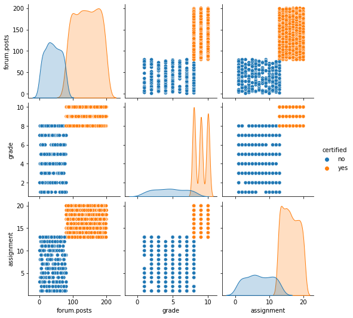

```python
sns.pairplot(mooc, hue = "certified")
```

```python
## INSERT YOUR COMMENT HERE: ##
```

There is a clear distinction between the students earned the certificate and the students who did not earn the certificate

To build the logistic regression model, we are going to import the LogisticRegression from the sklearn.linear_model.

```python
from sklearn.linear_model import LogisticRegression
```

But before building the logistic regression model, we still need to prepare the dataset a little bit. First step is to create a dummy variable for certified. We are going to use the pd.get_dummies() functions.

```python
dummy = pd.get_dummies(mooc['certified'], prefix = 'certified') # Here prefix = 'certified' will create new column names
dummy
```

|  | certified_no | certified_yes |
| --- | --- | --- |
| 0 | 1 | 0 |
| 1 | 1 | 0 |
| 2 | 0 | 1 |
| 3 | 0 | 1 |
| 4 | 0 | 1 |
| ... | ... | ... |
| 995 | 0 | 1 |
| 996 | 0 | 1 |
| 997 | 1 | 0 |
| 998 | 1 | 0 |
| 999 | 0 | 1 |

1000 rows × 2 columns

We really just need one column, so let's do a merge first and then drop the certified as it is no longer needed:

```python
moocD = pd.concat([mooc, dummy], axis=1)
moocD = moocD.drop(['certified', 'certified_no'], axis=1)
moocD
```

|  | forum.posts | grade | assignment | certified_yes |
| --- | --- | --- | --- | --- |
| 0 | 7 | 3 | 9 | 0 |
| 1 | 7 | 4 | 1 | 0 |
| 2 | 191 | 8 | 19 | 1 |
| 3 | 130 | 10 | 18 | 1 |
| 4 | 135 | 8 | 18 | 1 |
| ... | ... | ... | ... | ... |
| 995 | 88 | 10 | 13 | 1 |
| 996 | 153 | 10 | 19 | 1 |
| 997 | 41 | 4 | 3 | 0 |
| 998 | 47 | 6 | 12 | 0 |
| 999 | 112 | 8 | 19 | 1 |

1000 rows × 4 columns

Or here is a even quick way, very useful to create one-hot encoding for categorical varaibles

```python
mooc_dummies = pd.get_dummies(mooc, prefix='certified_recode', columns=['certified'])
mooc_dummies
```

|  | forum.posts | grade | assignment | certified_recode_no | certified_recode_yes |
| --- | --- | --- | --- | --- | --- |
| 0 | 7 | 3 | 9 | 1 | 0 |
| 1 | 7 | 4 | 1 | 1 | 0 |
| 2 | 191 | 8 | 19 | 0 | 1 |
| 3 | 130 | 10 | 18 | 0 | 1 |
| 4 | 135 | 8 | 18 | 0 | 1 |
| ... | ... | ... | ... | ... | ... |
| 995 | 88 | 10 | 13 | 0 | 1 |
| 996 | 153 | 10 | 19 | 0 | 1 |
| 997 | 41 | 4 | 3 | 1 | 0 |
| 998 | 47 | 6 | 12 | 1 | 0 |
| 999 | 112 | 8 | 19 | 0 | 1 |

1000 rows × 5 columns

```python
Xs = moocD[["forum.posts", "grade", "assignment"]].to_numpy()
certified = moocD.loc[:,"certified_yes"].values.reshape(-1, 1)
```

Then loading LogisticRegression() and calling for LogisticRegression.fit() is very similar to what we have done in the previous ICE.

```python
moocLogitModel1 = LogisticRegression()
moocLogitModel1.fit(Xs, certified)
```

```
LogisticRegression()
```

We can call for the intercept and coefficients of each parameter and we will have our logistic regression model.

```python
moocLogitModel1.intercept_
```

```
array([-63.13291439])
```

```python
moocLogitModel1.coef_
```

```
array([[0.62419697, 0.52270711, 0.85766257]])
```

If you want to see a nicer output, statsmodels.api proides an sm model, which does pretty much the same thing:

```python
import statsmodels.api as sm

moocLogitModel2 = sm.Logit(certified, Xs)
moocLogitModel2Fit = moocLogitModel2.fit()
print(moocLogitModel2Fit.summary())
```

```
Optimization terminated successfully.
         Current function value: 22.457768
         Iterations 7
                           Logit Regression Results
==============================================================================
Dep. Variable:                      y   No. Observations:                 1000
Model:                          Logit   Df Residuals:                      997
Method:                           MLE   Df Model:                            2
Date:                Mon, 20 Dec 2021   Pseudo R-squ.:                     inf
Time:                        01:48:08   Log-Likelihood:                -22458.
converged:                       True   LL-Null:                        0.0000
Covariance Type:            nonrobust   LLR p-value:                     1.000
==============================================================================
                 coef    std err          z      P>|z|      [0.025      0.975]
------------------------------------------------------------------------------
x1             0.0378      0.003     10.852      0.000       0.031       0.045
x2            -0.3202      0.047     -6.879      0.000      -0.411      -0.229
x3             0.0315      0.025      1.258      0.208      -0.018       0.081
==============================================================================
```

You probably have noticed that the results of two models are not identical. And you are absolutely correct. sklearn and statsmodels set the default logistic regression a little bit differently. The most obvious one is statsmodels does not estimate the intercept by default. Therefore, the results of all coefficient will be shifted. There are more differences such as the regularization parameter. See a discussion here on StackExchange: https://stats.stackexchange.com/questions/203740/logistic-regression-scikit-learn-vs-statsmodels

And here are the LogisticRegression documentation in sklearn and the Logit documentation in statsmodles. You may also want to read in detail if you are curious about what is happening under the hood.

But, does it matter if we get different results? Well... yes and no.

### Decision Tree

A Decision Tree is another supervised Machine learning algorithm. The decision tree is like a tree with nodes. The branches depend on a number of factors. It splits data into branches like these till it achieves a threshold value. A decision tree consists of the root nodes, children nodes, and leaf nodes.

Decision trees learn from data to approximate the training data with a set of if-then-else decision rules. The deeper the tree, the more complex the decision rules and the fitter the model.

Decision tree has various algorithms to implement. In sklearn, an optimised version of CART algorithm is used.

First, we need to import the DecisionTreeClassifier from sklearn.tree and then prepare the data.

```python
from sklearn.tree import DecisionTreeClassifier

Xs_tree = mooc.drop('certified', axis = 1)
certified = mooc['certified']
```

And similarly, initialize the classification tree model and then use the Xs and Y to train the model. Only two lines of code.

```python
moocTreeModel = DecisionTreeClassifier()
moocTreeModel.fit(Xs_tree, certified)
```

```
DecisionTreeClassifier()
```

Once we have the model, we have different ways to see what do we get. First, the text representation can be useful when working on applications whitout user interface or when we want to log information about the model into the text file. You can check details about export_text in the sklearn documentation.

```python
from sklearn import tree
text_representation = tree.export_text(moocTreeModel)
print(text_representation)
```

```
|--- feature_0 <= 79.50
|   |--- class: no
|--- feature_0 >  79.50
|   |--- feature_2 <= 11.00
|   |   |--- class: no
|   |--- feature_2 >  11.00
|   |   |--- class: yes
```

Or try a prettier way with plot_tree. This requires matplotlib. Make sure it is already loaded. It allows us to easily produce figure of the tree.

[output not shown]

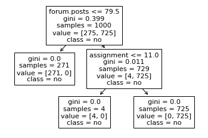

```python
tree.plot_tree(moocTreeModel,
              feature_names = ["forum.posts", "grade", "assignment"], # This is optional. Just let the plot know the features name.
                class_names = mooc.certified # This is also optional. Read more information in the documentation.
              )
```

### Naive Bayes

Naive Bayes models are a group of extremely fast and simple classification algorithms that are often suitable for very high-dimensional datasets. Because they are so fast and have so few tunable parameters, they end up being very useful as a quick-and-dirty baseline for a classification problem.

Naive Bayes classifiers are built on Bayesian classification methods. These rely on Bayes's theorem, which is an equation describing the relationship of conditional probabilities of statistical quantities. In Bayesian classification, we're interested in finding the probability of a label given some observed features.

If we are trying to decide between two labels—let's call them L1 and L2—then one way to make this decision is to compute the ratio of the posterior probabilities for each label.

All we need now is some model by which we can compute for each label. Such a model is called a generative model because it specifies the hypothetical random process that generates the data. Specifying this generative model for each label is the main piece of the training of such a Bayesian classifier. The general version of such a training step is a very difficult task, but we can make it simpler through the use of some simplifying assumptions about the form of this model.

This is where the "naive" in "naive Bayes" comes in: if we make very naive assumptions about the generative model for each label, we can find a rough approximation of the generative model for each class, and then proceed with the Bayesian classification.

Importing the GaussianNB from sklearn and create Xs and the Y.

```python
from sklearn.naive_bayes import GaussianNB

Xs_NB = mooc.drop('certified', axis = 1)
certified = mooc['certified']
```

Then, initialize the classification Naive Bayes model and then the same two lines of code.

```python
moocNBModel = GaussianNB()
moocNBModel.fit(Xs_NB, certified)
```

```
GaussianNB()
```

```python
certified_pred = moocNBModel.predict(Xs_NB)
# print(certified_pred)
performance = [item in certified_pred for item in certified]
# item in certified_pred -> boolean value
print('The accuracy is', sum(performance)/len(performance)*100, '%')
# sum(performance) = number of Trues
```

```
The accuracy is 100.0 %
```

```python
q = ['Yes', 'Yes', 'Yes']
a = ['No', 'No', 'Yes']
p = [x in q for x in a]
print(p)
```

```
[False, False, True]
```

### Model Evaluation

As discussed previously, we need a sample of data held back from training your model that is used to give an estimate of model performance.

In the machine learning world, this type of data is often called either validation data or test data as opposed to the training data, which was used to train the model.

At the basic level, our model is pretty simple and straightfoward. So there is no point to differentiate the validation data and the test data. In 4050, we will probably use these terms somewhat interchangeably. But notice that they are different. Read more here: https://www.applause.com/blog/training-data-validation-data-vs-test-data

We will talk about some more details of model evaluation in the next couple weeks. But let me introduce you to a simplistic way of knowing the model performance -- confusion matrix.

It is a performance measurement for machine learning classification problem where output can be two or more classes. It is a table with 4 different combinations of predicted and actual values.

True Positive: You predicted positive and it’s true. You predicted that a person has covid and he/she actually has.

True Negative: Interpretation: You predicted negative and it’s true. You predicted that a person does not have covid and he/she actually does not have it.

False Positive: (Type 1 Error) You predicted positive but it’s false. You predicted that a person has covid, but he/she actually does not have it.

False Negative: (Type 2 Error) You predicted negative but it’s true. You predicted that a person does not have covid, but he/she actually has it.

Once we have these four numbers, things become pretty easy. The simplistic measure would be accurracy. It basically tells us how often the classifier is correct.

Here are a couple of things we need to do:

1.Split the data into two sets (by convention it is 80:20, but it can be other ratio -- either larger or smaller depending on how many data points you have).

2.Re-train the models

3.Feed the Xs in the testing dataset and obtain the predicted Ys.

4.Compare the predicted Ys with what is actually in the testing dataset (the ground truth) and obtain the confusion matrix.

5.Obtain the accuracy from the confusion matrix.

**Step 1.** Split data (we need to do things a little bit differently for logistic regression model and the decision tree or Naive Bayes model because the latter two can handle categorical data without requiring dummy coding.

```python
from sklearn.model_selection import train_test_split

## For logistic regression
Xs_logit = moocD[["forum.posts", "grade", "assignment"]].to_numpy()
certified_logit = moocD.loc[:,"certified_yes"].values.reshape(-1, 1)
xs_logit_training, xs_logit_test, y_logit_training, y_logit_test = train_test_split(Xs_logit, certified_logit, test_size = 0.2)

## For decision tree and Naive Bayes
Xs_TNB = mooc.drop('certified', axis = 1)
certified_TNB = mooc['certified']
xs_TNB_training, xs_TNB_test, y_TNB_training, y_TNB_test = train_test_split(Xs_TNB, certified_TNB, test_size = 0.2)
```

**Step 2.** Re-train the model with just the training data.

```python
# Logistic regression with sklearn
moocLogitModel1 = LogisticRegression()
moocLogitModel1.fit(xs_logit_training, y_logit_training)

# Logistic regression with statsmodels
moocLogitModel2 = sm.Logit(y_logit_training, xs_logit_training)
moocLogitModel2Fit = moocLogitModel2.fit()
print(moocLogitModel2Fit.summary())

# Decision Tree
moocTreeModel = DecisionTreeClassifier()
moocTreeModel.fit(xs_TNB_training, y_TNB_training)

# Naive Bayes
moocNBModel = GaussianNB()
moocNBModel.fit(xs_TNB_training, y_TNB_training)
```

```
Optimization terminated successfully.
         Current function value: 18.984291
         Iterations 7
                           Logit Regression Results
==============================================================================
Dep. Variable:                      y   No. Observations:                  800
Model:                          Logit   Df Residuals:                      797
Method:                           MLE   Df Model:                            2
Date:                Mon, 20 Dec 2021   Pseudo R-squ.:                     inf
Time:                        01:48:08   Log-Likelihood:                -15187.
converged:                       True   LL-Null:                        0.0000
Covariance Type:            nonrobust   LLR p-value:                     1.000
==============================================================================
                 coef    std err          z      P>|z|      [0.025      0.975]
------------------------------------------------------------------------------
x1             0.0387      0.004      9.538      0.000       0.031       0.047
x2            -0.2993      0.053     -5.670      0.000      -0.403      -0.196
x3             0.0167      0.028      0.595      0.552      -0.038       0.072
==============================================================================
```

```
GaussianNB()
```

**Step 3.** Feed the Xs in the testing dataset and obtain the predicted Ys.

```python
# Predicted value in sklearn logistic regression model
certified_pred_logit1 = moocLogitModel1.predict(xs_logit_test)

# Predicted value in statsmodels logistic regression model
certified_pred_logit2 = moocLogitModel2Fit.predict(xs_logit_test)

# Predicted value in decision tree model
certified_pred_tree = moocTreeModel.predict(xs_TNB_test)

# Predicted value in naive bayes model
certified_pred_NB = moocNBModel.predict(xs_TNB_test)
```

**Step 4.** Compare the predicted Ys with what is actually in the testing dataset (the ground truth) and obtain the confusion matrix.

```python
from sklearn.metrics import confusion_matrix
```

```python
# sklearn logistic regression model confusion matrix
print(confusion_matrix(y_logit_test, certified_pred_logit1))
```

```
[[ 64   0]
 [  0 136]]
```

```python
# certified_pred_logit2.round()
```

```python
# statsmodels logistic regression model confusion matrix
print(confusion_matrix(y_logit_test, certified_pred_logit2.round()))
```

```
[[ 28  36]
 [  0 136]]
```

```python
# decision tree model confusion matrix
print(confusion_matrix(y_TNB_test, certified_pred_tree))
```

```
[[ 62   0]
 [  0 138]]
```

```python
# Naive Bayes confusion matrix
print(confusion_matrix(y_TNB_test, certified_pred_NB))
```

```
[[ 62   0]
 [  0 138]]
```

Note here, two logistic regression model used the same testing dataset and the decision tree and naive bayes model used the same testing dataset. That's why the confusion matrices look different.

**Step 5.** Obtaining accuracy score

```python
from sklearn.metrics import accuracy_score
ac_logit1 = accuracy_score(y_logit_test, certified_pred_logit1)
ac_logit2 = accuracy_score(y_logit_test, certified_pred_logit2.round())
ac_tree = accuracy_score(y_TNB_test, certified_pred_tree)
ac_NB = accuracy_score(y_TNB_test, certified_pred_NB)

print("The accuracy for logistic regression in sklearn is", ac_logit1*100, "%")
print("The accuracy for logistic regression in statsmodels is", ac_logit2*100, "%")
print("The accuracy for decision tree", ac_tree*100, "%")
print("The accuracy for naive bayes", ac_NB*100, "%")
```

```
The accuracy for logistic regression in sklearn is 100.0 %
The accuracy for logistic regression in statsmodels is 82.0 %
The accuracy for decision tree 100.0 %
The accuracy for naive bayes 100.0 %
```

```python
A = [1,2,3,4,5]
B = [1,2,3,5,4]
p = [item in A for item in B]
print(p)

p2 = [A[i] == B[i] for i in range(len(A))]
print(p2)
```

```
[True, True, True, True, True]
[True, True, True, False, False]
```